# Assignment 4

Dans Lismanis

2023-10-19

## Question 1

```r
df=read.csv("/Users/dans/Desktop/ECON/econ_assignment_4/oj.csv")
lp=log(df$price)
library(fastDummies)
df=dummy_cols(df, select_columns ='brand')
df$featdom=df$feat*df$brand_dominicks
df$featminu=df$feat*df$brand_minute.maid
df$feattro=df$feat*df$brand_tropicana

df$dom_lp=lp*df$brand_dominicks
df$min_lp=lp*df$brand_minute.maid
df$tro_lp=lp*df$brand_tropicana

df1=df
df1$week=df1$week+1
df2=merge(df,df1, by=c("brand","store","week"))
colnames(df2)[colnames(df2)=="price.y"]="LagPrice"
colnames(df2)[colnames(df2)=="price.x"]="Price"
df2$LnPrice=log(df2$Price)
df2$LnLagPrice=log(df2$LagPrice)
df2$Lagxcurrent=(df2$LnPrice)*(df2$LnLagPrice)


reg1=lm(logmove.x~ LnPrice+LnLagPrice+min_lp.x+tro_lp.x+feat.x+brand_minute.maid.x+brand_tropicana.x+AGE60.x+EDUC.x+ETHNIC.x+INCOME.x+HHLARGE.x+WORKWOM.x+HVAL150.x, data=df2)
summary(reg1)
```

```
##
## Call:
## lm(formula = logmove.x ~ LnPrice + LnLagPrice + min_lp.x + tro_lp.x +
##     feat.x + brand_minute.maid.x + brand_tropicana.x + AGE60.x +
##     EDUC.x + ETHNIC.x + INCOME.x + HHLARGE.x + WORKWOM.x + HVAL150.x,
##     data = df2)
##
## Residuals:
##     Min      1Q  Median      3Q     Max
## -5.0968 -0.4087 -0.0023  0.3921  3.0467
##
## Coefficients:
##                     Estimate Std. Error t value Pr(>|t|)
## (Intercept)         11.92720    0.31673  37.657  < 2e-16 ***
## LnPrice             -3.18778    0.03276 -97.321  < 2e-16 ***
## LnLagPrice           0.51364    0.02166  23.713  < 2e-16 ***
## min_lp.x             0.27151    0.04970   5.463 4.72e-08 ***
## tro_lp.x             0.77306    0.04627  16.707  < 2e-16 ***
## feat.x               0.82896    0.01044  79.398  < 2e-16 ***
## brand_minute.maid.x  0.49452    0.03629  13.626  < 2e-16 ***
## brand_tropicana.x    0.55555    0.04080  13.617  < 2e-16 ***
## AGE60.x              1.42207    0.12811  11.100  < 2e-16 ***
## EDUC.x               0.50986    0.10121   5.037 4.75e-07 ***
## ETHNIC.x             0.55229    0.03651  15.128  < 2e-16 ***
## INCOME.x            -0.13855    0.03172  -4.367 1.26e-05 ***
## HHLARGE.x           -1.24887    0.23616  -5.288 1.24e-07 ***
## WORKWOM.x           -1.39511    0.14448  -9.656  < 2e-16 ***
## HVAL150.x            0.36632    0.04071   8.998  < 2e-16 ***
## ---
## Signif. codes:  0 '***' 0.001 '**' 0.01 '*' 0.05 '.' 0.1 ' ' 1
##
## Residual standard error: 0.6702 on 27993 degrees of freedom
## Multiple R-squared:  0.5687, Adjusted R-squared:  0.5684
## F-statistic:  2636 on 14 and 27993 DF,  p-value: < 2.2e-16
```

```r
MSE_lm=mean((df2$logmove.x-predict(reg1))^2)
```

### a)

```r
library(glmnet)
```

### b)

```r
set.seed(720)
df_RHS=df2[c('LnPrice',"LnLagPrice","Lagxcurrent","min_lp.x","tro_lp.x","feat.x","brand_minute.maid.x","brand_tropicana.x","AGE60.x","EDUC.x","ETHNIC.x","INCOME.x","HHLARGE.x","WORKWOM.x","HVAL150.x")]
y=df2[["logmove.x"]]
x=as.matrix(df_RHS)
```

### c)

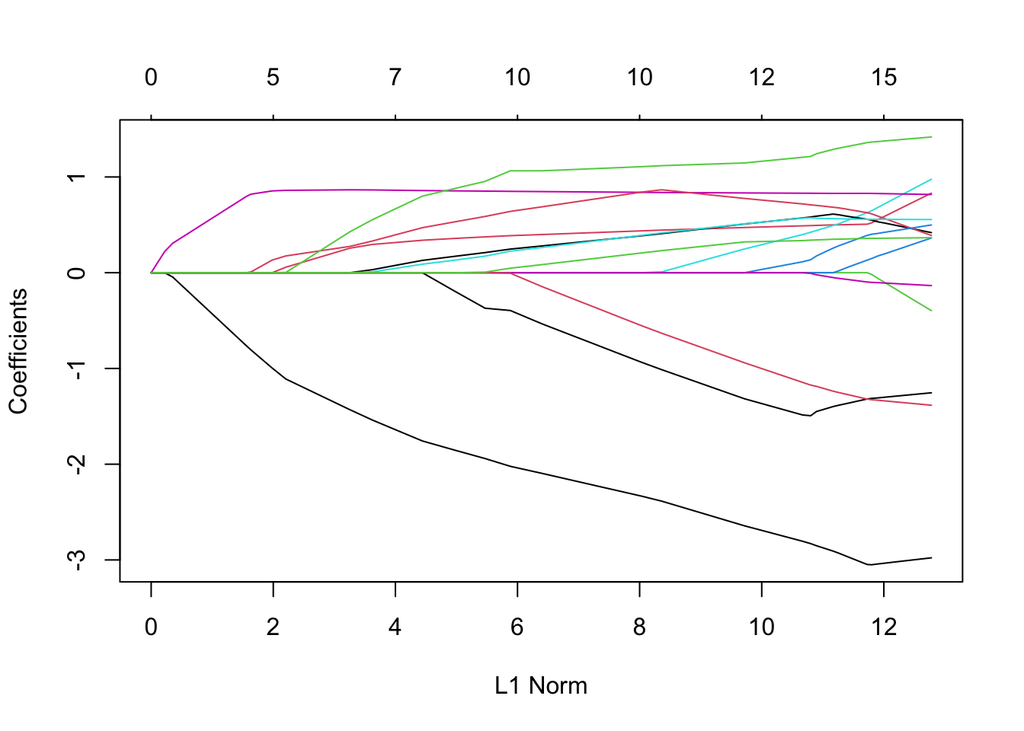

```r
set.seed(720)
#lasso_v1 <- cv.glmnet(x, y, alpha=1)
lasso_v1 <- glmnet(x, y, alpha=1)

#Results
plot(lasso_v1)
```

```r
coef(lasso_v1, s=lasso_v1$lambda.min)
```

```
## 16 x 80 sparse Matrix of class "dgCMatrix"
```

```
##   [[ suppressing 80 column names 's0', 's1', 's2' ... ]]
```

[output not shown]

[output cut: 234 more lines]

```
## LnPrice             -2.9780431
## LnLagPrice           0.8305164
## Lagxcurrent         -0.3960699
## min_lp.x             0.3622701
## tro_lp.x             0.9759510
## feat.x               0.8170819
## brand_minute.maid.x  0.4186733
## brand_tropicana.x    0.3890829
## AGE60.x              1.4174220
## EDUC.x               0.4986194
## ETHNIC.x             0.5553617
## INCOME.x            -0.1343679
## HHLARGE.x           -1.2543247
## WORKWOM.x           -1.3843080
## HVAL150.x            0.3659034
```

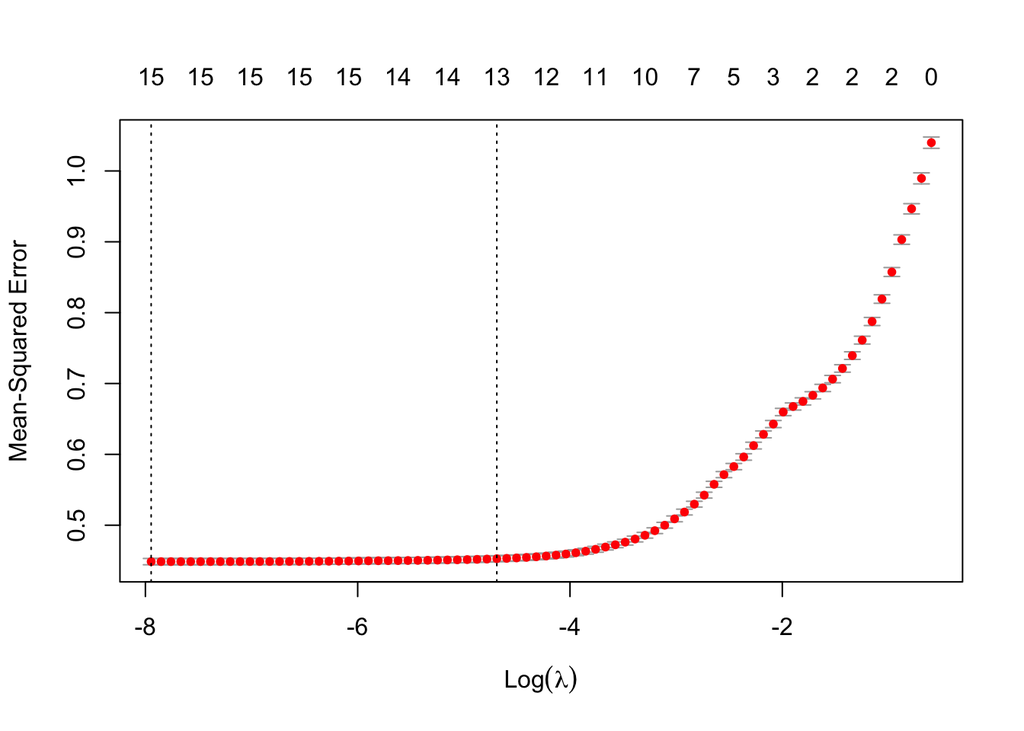

```r
# Now ready for cross validation version of the object
cvfit <- cv.glmnet(x, y, alpha=1)
#Results
plot(cvfit)
```

```r
cvfit$lambda.min
```

```
## [1] 0.0003542151
```

```r
log(cvfit$lambda.min)
```

```
## [1] -7.945606
```

```r
coef(cvfit, s = "lambda.min")
```

```
## 16 x 1 sparse Matrix of class "dgCMatrix"
##                             s1
## (Intercept)         11.7252444
## LnPrice             -2.9780431
## LnLagPrice           0.8305164
## Lagxcurrent         -0.3960699
## min_lp.x             0.3622701
## tro_lp.x             0.9759510
## feat.x               0.8170819
## brand_minute.maid.x  0.4186733
## brand_tropicana.x    0.3890829
## AGE60.x              1.4174220
## EDUC.x               0.4986194
## ETHNIC.x             0.5553617
## INCOME.x            -0.1343679
## HHLARGE.x           -1.2543247
## WORKWOM.x           -1.3843080
## HVAL150.x            0.3659034
```

### d)

And MSE for lm model is

```r
MSE_lm
```

```
## [1] 0.4489607
```

### e)

Using Lasso we can decide what regressors trully matter, which ones are most important. We use our economic intuition to decide which parameters to investigate in the first place.

## Question 2:

```r
reg2=lm(logmove.x~ LnPrice+LnLagPrice+Lagxcurrent+min_lp.x+tro_lp.x+feat.x+brand_minute.maid.x+brand_tropicana.x+AGE60.x+EDUC.x+ETHNIC.x+INCOME.x+HHLARGE.x+WORKWOM.x+HVAL150.x, data=df2)
summary(reg2)
```

```
##
## Call:
## lm(formula = logmove.x ~ LnPrice + LnLagPrice + Lagxcurrent +
##     min_lp.x + tro_lp.x + feat.x + brand_minute.maid.x + brand_tropicana.x +
##     AGE60.x + EDUC.x + ETHNIC.x + INCOME.x + HHLARGE.x + WORKWOM.x +
##     HVAL150.x, data = df2)
##
## Residuals:
##     Min      1Q  Median      3Q     Max
## -5.0166 -0.4121 -0.0010  0.3927  3.0355
##
## Coefficients:
##                     Estimate Std. Error t value Pr(>|t|)
## (Intercept)         11.75128    0.31728  37.038  < 2e-16 ***
## LnPrice             -2.95990    0.04458 -66.394  < 2e-16 ***
## LnLagPrice           0.91028    0.05697  15.979  < 2e-16 ***
## Lagxcurrent         -0.49285    0.06548  -7.527 5.36e-14 ***
## min_lp.x             0.42324    0.05359   7.898 2.93e-15 ***
## tro_lp.x             1.07191    0.06094  17.591  < 2e-16 ***
## feat.x               0.81445    0.01061  76.786  < 2e-16 ***
## brand_minute.maid.x  0.37890    0.03938   9.622  < 2e-16 ***
## brand_tropicana.x    0.31768    0.05158   6.159 7.40e-10 ***
## AGE60.x              1.42439    0.12798  11.130  < 2e-16 ***
## EDUC.x               0.51392    0.10112   5.083 3.75e-07 ***
## ETHNIC.x             0.55501    0.03647  15.217  < 2e-16 ***
## INCOME.x            -0.13924    0.03169  -4.393 1.12e-05 ***
## HHLARGE.x           -1.24634    0.23593  -5.283 1.28e-07 ***
## WORKWOM.x           -1.39320    0.14434  -9.652  < 2e-16 ***
## HVAL150.x            0.36631    0.04067   9.006  < 2e-16 ***
## ---
## Signif. codes:  0 '***' 0.001 '**' 0.01 '*' 0.05 '.' 0.1 ' ' 1
##
## Residual standard error: 0.6696 on 27992 degrees of freedom
## Multiple R-squared:  0.5695, Adjusted R-squared:  0.5693
## F-statistic:  2469 on 15 and 27992 DF,  p-value: < 2.2e-16
```

### a)

#### iii)

-0.16+0.81=0.65

#### iv)

```r
inter=confint(reg1)
print(inter)
```

```
##                          2.5 %      97.5 %
## (Intercept)         11.3063936 12.54800047
## LnPrice             -3.2519822 -3.12357870
## LnLagPrice           0.4711837  0.55609756
## min_lp.x             0.1740947  0.36891851
## tro_lp.x             0.6823672  0.86375690
## feat.x               0.8084985  0.84942640
## brand_minute.maid.x  0.4233829  0.56565562
## brand_tropicana.x    0.4755851  0.63552115
## AGE60.x              1.1709690  1.67316685
## EDUC.x               0.3114715  0.70824188
## ETHNIC.x             0.4807350  0.62384851
## INCOME.x            -0.2007330 -0.07636942
## HHLARGE.x           -1.7117566 -0.78597418
## WORKWOM.x           -1.6782951 -1.11191545
## HVAL150.x            0.2865221  0.44612445
```

### b)

DOminicks orange juice has the most elastic demand, this means that it must have the lowest markup against costs, this is because increasing markup signicifantly decreases demand.

## Question 3

### a)

Data preperation

```r
df2$dfeatlp=df2$brand_dominicks.x*df2$feat.x*df2$LagPrice
df2$mfeatlp=df2$brand_minute.maid.x*df2$feat.x*df2$LnPrice
df2$tfeatlp=df2$brand_tropicana.x*df2$feat.x*df2$LnPrice
domdata=df2[df2$brand_dominicks.x==1,]
minudata=df2[df2$brand_minute.maid.x==1,]
trodata=df2[df2$brand_tropicana.x==1,]

x1=as.matrix(domdata[c("LnPrice","AGE60.x","EDUC.x","ETHNIC.x","INCOME.x","HHLARGE.x","WORKWOM.x","HVAL150.x")])
x2=as.matrix(minudata[c("LnPrice","AGE60.x","EDUC.x","ETHNIC.x","INCOME.x","HHLARGE.x","WORKWOM.x","HVAL150.x")])
x3=as.matrix(trodata[c("LnPrice","AGE60.x","EDUC.x","ETHNIC.x","INCOME.x","HHLARGE.x","WORKWOM.x","HVAL150.x")])

y1=domdata[["logmove.x"]]
y2=minudata[["logmove.x"]]
y3=trodata[["logmove.x"]]
p1=domdata[["LnPrice"]]
p2=minudata[["LnPrice"]]
p3=trodata[["LnPrice"]]


x1=cbind(x1,p2)
x1=cbind(x1,p3)
x2=cbind(x2,p1)
x2=cbind(x2,p3)
x3=cbind(x3,p1)
x3=cbind(x3,p2)
```

Regression for dominicks

```r
lasso_dom=glmnet(x1,y1,alpha = 1)
domfita <- cv.glmnet(x1, y1, alpha=1)
domfita$lambda.min
```

```
## [1] 0.001781473
```

```r
log(domfita$lambda.min)
```

```
## [1] -6.330315
```

```r
coef(domfita, s = "lambda.min")
```

```
## 11 x 1 sparse Matrix of class "dgCMatrix"
##                       s1
## (Intercept) 10.703193238
## LnPrice     -3.574838226
## AGE60.x      0.555005990
## EDUC.x       .
## ETHNIC.x     0.733224488
## INCOME.x    -0.001541083
## HHLARGE.x   -1.654097733
## WORKWOM.x   -1.286991628
## HVAL150.x   -0.539462574
## p2           1.236965878
## p3           0.032185250
```

Regression for minutemaid

```r
lasso_min=glmnet(x2,y2,alpha = 1)
minfita <- cv.glmnet(x2, y2, alpha=1)
minfita$lambda.min
```

```
## [1] 0.001287611
```

```r
log(minfita$lambda.min)
```

```
## [1] -6.654967
```

```r
coef(minfita, s = "lambda.min")
```

```
## 11 x 1 sparse Matrix of class "dgCMatrix"
##                      s1
## (Intercept) 10.89619347
## LnPrice     -3.92849057
## AGE60.x      1.51944558
## EDUC.x       0.39444864
## ETHNIC.x     0.60096891
## INCOME.x    -0.03194642
## HHLARGE.x   -0.54341134
## WORKWOM.x   -0.98173422
## HVAL150.x    0.45718425
## p1           0.85170195
## p3           1.09453978
```

Regression for tropicana

```r
lasso_tro=glmnet(x3,y3,alpha = 1)
trofita <- cv.glmnet(x3, y3, alpha=1)
trofita$lambda.min
```

```
## [1] 0.001195792
```

```r
log(trofita$lambda.min)
```

```
## [1] -6.728947
```

```r
coef(trofita, s = "lambda.min")
```

```
## 11 x 1 sparse Matrix of class "dgCMatrix"
##                     s1
## (Intercept) 15.2852756
## LnPrice     -3.0048052
## AGE60.x      2.1898955
## EDUC.x       0.9435540
## ETHNIC.x     0.3267696
## INCOME.x    -0.3423376
## HHLARGE.x   -1.3770544
## WORKWOM.x   -1.7357126
## HVAL150.x    1.2231690
## p1           0.1749148
## p2           0.2472492
```

#### Matrix

```r
mat2a=as.matrix(coef(domfita))[c(2,10,11),]
t2=
mat2a=rbind(mat2a,as.matrix(coef(minfita))[c(2,10,11),][c(2,1,3)])
mat2a=rbind(mat2a,as.matrix(coef(trofita))[c(2,10,11),][c(2,3,1)])
colnames(mat2a)=c("p1","p2","p3")
rownames(mat2a)=c("Dominicks","MinuteMaid","Tropicana")
mat2a
```

```
##                    p1         p2         p3
## Dominicks  -3.3249758  0.9524627  0.0000000
## MinuteMaid  0.7631434 -3.7238174  0.9855826
## Tropicana   0.1061650  0.1508538 -2.8492033
```

### b)

```r
x1=as.matrix(domdata[c("LnPrice","featdom.x","dfeatlp","featminu.x","mfeatlp","feattro.x","tfeatlp","AGE60.x","EDUC.x","ETHNIC.x","INCOME.x","HHLARGE.x","WORKWOM.x","HVAL150.x")])
x2=as.matrix(minudata[c("LnPrice","featdom.x","dfeatlp","featminu.x","mfeatlp","feattro.x","tfeatlp","AGE60.x","EDUC.x","ETHNIC.x","INCOME.x","HHLARGE.x","WORKWOM.x","HVAL150.x")])
x3=as.matrix(trodata[c("LnPrice","featdom.x","dfeatlp","featminu.x","mfeatlp","feattro.x","tfeatlp","AGE60.x","EDUC.x","ETHNIC.x","INCOME.x","HHLARGE.x","WORKWOM.x","HVAL150.x")])
x1=cbind(x1,p2)
x1=cbind(x1,p3)
x2=cbind(x2,p1)
x2=cbind(x2,p3)
x3=cbind(x3,p1)
x3=cbind(x3,p2)
```

Regression for dominicks

```r
lasso_dom=glmnet(x1,y1,alpha = 1)
domfit <- cv.glmnet(x1, y1, alpha=1)
domfit$lambda.min
```

```
## [1] 0.002355003
```

```r
log(domfit$lambda.min)
```

```
## [1] -6.051213
```

```r
coef(domfit, s = "lambda.min")
```

```
## 17 x 1 sparse Matrix of class "dgCMatrix"
##                        s1
## (Intercept) 10.4050407867
## LnPrice     -3.0552795562
## featdom.x    0.4838985249
## dfeatlp      0.2226914595
## featminu.x   .
## mfeatlp      .
## feattro.x    .
## tfeatlp      .
## AGE60.x      0.4504626473
## EDUC.x       .
## ETHNIC.x     0.6893766193
## INCOME.x     .
## HHLARGE.x   -1.5934110424
## WORKWOM.x   -1.2880013432
## HVAL150.x   -0.5686565206
## p2           1.0443378482
## p3          -0.0001939579
```

Regression for minutemaid

```r
lasso_min=glmnet(x2,y2,alpha = 1)
minfit <- cv.glmnet(x2, y2, alpha=1)
minfit$lambda.min
```

```
## [1] 0.0005536065
```

```r
log(minfit$lambda.min)
```

```
## [1] -7.499056
```

```r
coef(minfit, s = "lambda.min")
```

```
## 17 x 1 sparse Matrix of class "dgCMatrix"
##                        s1
## (Intercept) 10.1074775126
## LnPrice     -2.5994262636
## featdom.x    .
## dfeatlp      .
## featminu.x   1.7481015819
## mfeatlp     -1.0365454054
## feattro.x    .
## tfeatlp      .
## AGE60.x      1.3951915561
## EDUC.x       0.4073506668
## ETHNIC.x     0.6019175515
## INCOME.x    -0.0007659496
## HHLARGE.x   -0.7334897657
## WORKWOM.x   -1.1058676708
## HVAL150.x    0.4080859447
## p1           0.5933737211
## p3           0.4640501770
```

Regression for tropicana

```r
lasso_tro=glmnet(x3,y3,alpha = 1)
trofit <- cv.glmnet(x3, y3, alpha=1)
trofit$lambda.min
```

```
## [1] 0.0004297452
```

```r
log(trofit$lambda.min)
```

```
## [1] -7.752318
```

```r
coef(trofit, s = "lambda.min")
```

```
## 17 x 1 sparse Matrix of class "dgCMatrix"
##                      s1
## (Intercept) 14.46185291
## LnPrice     -2.38967931
## featdom.x    .
## dfeatlp      .
## featminu.x   .
## mfeatlp      .
## feattro.x    1.61784527
## tfeatlp     -1.24492937
## AGE60.x      2.06637291
## EDUC.x       0.93206414
## ETHNIC.x     0.30690079
## INCOME.x    -0.31690028
## HHLARGE.x   -1.53216922
## WORKWOM.x   -1.79868710
## HVAL150.x    1.17764086
## p1           0.08635061
## p2           0.19054922
```

#### Matrix

```r
mat3b=as.matrix(coef(domfit))[c(2,16,17),]
mat3b=rbind(mat3b,as.matrix(coef(minfit))[c(2,16,17),][c(2,1,3)])
mat3b=rbind(mat3b,as.matrix(coef(trofit))[c(2,16,17),][c(2,3,1)])
colnames(mat3b)=c("p1","p2","p3")
rownames(mat3b)=c("Dominicks","MinuteMaid","Tropicana")
mat3b
```

```
##                     p1         p2         p3
## Dominicks  -2.80478918  0.7092853  0.0000000
## MinuteMaid  0.57949484 -2.7772467  0.4868949
## Tropicana   0.07640357  0.1442336 -2.4625203
```

#### i)

The elasticities decrease affter feature is introduced as one of the regressors.

#### ii)

Dominicks suffers most when Minute Maid decreases its price and is on sale, as they have the greater cross elasticities.

### c)

Minute Maid and Dominicks are the most competitive with each other.

#### i)

this can be seen as their cross elasticieties are the largest.

#### ii)

I would expect their prices to move close together, as a decrease in ones price leads to a lot of lost sales for the other.

They would be more closely related than the other pairs of products.

## Question 4

### a)

```r
df2$sales=exp(df2$logmove.x)
```

### b)

```r
library(plyr)
Df3 <- ddply(df2, c('store','week'),function(x) c(weighted_mean = weighted.mean(x$Price,x$sales)))
dataf <- merge(df2, Df3, by = c("store", "week"))
```

## Question 5

### a)

```r
library(rpart)
library(maptree)
```

### b)

```r
dataToPass<-dataf[,c("weighted_mean","AGE60.x","EDUC.x","ETHNIC.x","INCOME.x","HHLARGE.x","WORKWOM.x","HVAL150.x","SSTRDIST.x","SSTRVOL.x","CPDIST5.x","CPWVOL5.x")]
#The above creates a dataframe from the existing one (with weighted mean merged back in) which will then be passed into rpart (tree partitioning algorithm).

fit<-rpart(as.formula(weighted_mean ~ .),data=dataToPass,method="anova",cp=0.007)
```

### c)

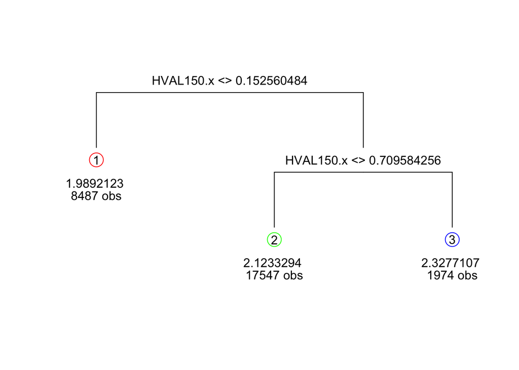

```r
draw.tree(fit)
```

### d)

```r
dataToPass$leaf = fit$where #This assigns leaves to observations.
```

```r
dataf$leaf=fit$where
leaf2=dataf[dataf$leaf==2,]
leaf4=dataf[dataf$leaf==4,]
leaf5=dataf[dataf$leaf==5,]
l2=lm(logmove.x~LnPrice+featdom.x+featminu.x+feattro.x,data=leaf2)
summary(l2)
```

```
##
## Call:
## lm(formula = logmove.x ~ LnPrice + featdom.x + featminu.x + feattro.x,
##     data = leaf2)
##
## Residuals:
##     Min      1Q  Median      3Q     Max
## -4.9145 -0.4711  0.0164  0.5059  3.2934
##
## Coefficients:
##             Estimate Std. Error t value Pr(>|t|)
## (Intercept) 10.43998    0.02761  378.08   <2e-16 ***
## LnPrice     -1.95559    0.03212  -60.89   <2e-16 ***
## featdom.x    0.85155    0.03276   25.99   <2e-16 ***
## featminu.x   1.19729    0.02864   41.80   <2e-16 ***
## feattro.x    1.03098    0.03675   28.05   <2e-16 ***
## ---
## Signif. codes:  0 '***' 0.001 '**' 0.01 '*' 0.05 '.' 0.1 ' ' 1
##
## Residual standard error: 0.7675 on 8482 degrees of freedom
## Multiple R-squared:  0.5126, Adjusted R-squared:  0.5124
## F-statistic:  2230 on 4 and 8482 DF,  p-value: < 2.2e-16
```

```r
l4=lm(logmove.x~LnPrice+featdom.x+featminu.x+feattro.x,data=leaf2)
summary(l4)
```

```
##
## Call:
## lm(formula = logmove.x ~ LnPrice + featdom.x + featminu.x + feattro.x,
##     data = leaf2)
##
## Residuals:
##     Min      1Q  Median      3Q     Max
## -4.9145 -0.4711  0.0164  0.5059  3.2934
##
## Coefficients:
##             Estimate Std. Error t value Pr(>|t|)
## (Intercept) 10.43998    0.02761  378.08   <2e-16 ***
## LnPrice     -1.95559    0.03212  -60.89   <2e-16 ***
## featdom.x    0.85155    0.03276   25.99   <2e-16 ***
## featminu.x   1.19729    0.02864   41.80   <2e-16 ***
## feattro.x    1.03098    0.03675   28.05   <2e-16 ***
## ---
## Signif. codes:  0 '***' 0.001 '**' 0.01 '*' 0.05 '.' 0.1 ' ' 1
##
## Residual standard error: 0.7675 on 8482 degrees of freedom
## Multiple R-squared:  0.5126, Adjusted R-squared:  0.5124
## F-statistic:  2230 on 4 and 8482 DF,  p-value: < 2.2e-16
```

```r
l5=lm(logmove.x~LnPrice+featdom.x+featminu.x+feattro.x,data=leaf2)
summary(l5)
```

```
##
## Call:
## lm(formula = logmove.x ~ LnPrice + featdom.x + featminu.x + feattro.x,
##     data = leaf2)
##
## Residuals:
##     Min      1Q  Median      3Q     Max
## -4.9145 -0.4711  0.0164  0.5059  3.2934
##
## Coefficients:
##             Estimate Std. Error t value Pr(>|t|)
## (Intercept) 10.43998    0.02761  378.08   <2e-16 ***
## LnPrice     -1.95559    0.03212  -60.89   <2e-16 ***
## featdom.x    0.85155    0.03276   25.99   <2e-16 ***
## featminu.x   1.19729    0.02864   41.80   <2e-16 ***
## feattro.x    1.03098    0.03675   28.05   <2e-16 ***
## ---
## Signif. codes:  0 '***' 0.001 '**' 0.01 '*' 0.05 '.' 0.1 ' ' 1
##
## Residual standard error: 0.7675 on 8482 degrees of freedom
## Multiple R-squared:  0.5126, Adjusted R-squared:  0.5124
## F-statistic:  2230 on 4 and 8482 DF,  p-value: < 2.2e-16
```

### a)

```r
leaf2dom=leaf2[leaf2$brand=="dominicks",]
leaf2minu=leaf2[leaf2$brand=="minute.maid",]
leaf2tro=leaf2[leaf2$brand=="tropicana",]

leaf2dom$m=leaf2minu["LnPrice"]
leaf2dom$t=leaf2tro["LnPrice"]

leaf2minu$d=leaf2dom["LnPrice"]
leaf2minu$t=leaf2tro["LnPrice"]

leaf2tro$d=leaf2dom["LnPrice"]
leaf2tro$m=leaf2minu["LnPrice"]
```

Dominicks:

```r
l2d=lm(logmove.x~LnPrice+m$LnPrice+t$LnPrice+featdom.x+featminu.x+feattro.x,data=leaf2dom)
summary(l2d)
```

```
##
## Call:
## lm(formula = logmove.x ~ LnPrice + m$LnPrice + t$LnPrice + featdom.x +
##     featminu.x + feattro.x, data = leaf2dom)
##
## Residuals:
##     Min      1Q  Median      3Q     Max
## -5.2680 -0.5150  0.0348  0.5392  2.6751
##
## Coefficients: (2 not defined because of singularities)
##             Estimate Std. Error t value Pr(>|t|)
## (Intercept) 10.09311    0.10159  99.347   <2e-16 ***
## LnPrice     -3.18508    0.08034 -39.646   <2e-16 ***
## m$LnPrice    1.15777    0.09626  12.027   <2e-16 ***
## t$LnPrice   -0.09363    0.08689  -1.077    0.281
## featdom.x    0.90572    0.03835  23.619   <2e-16 ***
## featminu.x        NA         NA      NA       NA
## feattro.x         NA         NA      NA       NA
## ---
## Signif. codes:  0 '***' 0.001 '**' 0.01 '*' 0.05 '.' 0.1 ' ' 1
##
## Residual standard error: 0.8521 on 2824 degrees of freedom
## Multiple R-squared:  0.5079, Adjusted R-squared:  0.5072
## F-statistic: 728.8 on 4 and 2824 DF,  p-value: < 2.2e-16
```

Minute Maid

```r
l2m=lm(logmove.x~LnPrice+d$LnPrice+t$LnPrice+featdom.x+featminu.x+feattro.x,data=leaf2minu)
summary(l2m)
```

```
##
## Call:
## lm(formula = logmove.x ~ LnPrice + d$LnPrice + t$LnPrice + featdom.x +
##     featminu.x + feattro.x, data = leaf2minu)
##
## Residuals:
##      Min       1Q   Median       3Q      Max
## -2.23797 -0.38759 -0.02648  0.35682  2.65575
##
## Coefficients: (2 not defined because of singularities)
##             Estimate Std. Error t value Pr(>|t|)
## (Intercept) 10.48561    0.07579 138.351   <2e-16 ***
## LnPrice     -3.26286    0.07701 -42.369   <2e-16 ***
## d$LnPrice    0.69973    0.05816  12.032   <2e-16 ***
## t$LnPrice    0.56137    0.06700   8.379   <2e-16 ***
## featdom.x         NA         NA      NA       NA
## featminu.x   1.07717    0.02874  37.485   <2e-16 ***
## feattro.x         NA         NA      NA       NA
## ---
## Signif. codes:  0 '***' 0.001 '**' 0.01 '*' 0.05 '.' 0.1 ' ' 1
##
## Residual standard error: 0.6364 on 2824 degrees of freedom
## Multiple R-squared:  0.6443, Adjusted R-squared:  0.6438
## F-statistic:  1279 on 4 and 2824 DF,  p-value: < 2.2e-16
```

Tropicana

```r
l2t=lm(logmove.x~LnPrice+d$LnPrice+m$LnPrice+featdom.x+featminu.x+feattro.x,data=leaf2tro)
summary(l2t)
```

```
##
## Call:
## lm(formula = logmove.x ~ LnPrice + d$LnPrice + m$LnPrice + featdom.x +
##     featminu.x + feattro.x, data = leaf2tro)
##
## Residuals:
##      Min       1Q   Median       3Q      Max
## -2.84162 -0.42642  0.05036  0.39652  3.15464
##
## Coefficients: (2 not defined because of singularities)
##             Estimate Std. Error t value Pr(>|t|)
## (Intercept) 11.65573    0.07476 155.918  < 2e-16 ***
## LnPrice     -3.09620    0.06666 -46.449  < 2e-16 ***
## d$LnPrice    0.18595    0.05404   3.441 0.000589 ***
## m$LnPrice    0.21581    0.06716   3.213 0.001328 **
## featdom.x         NA         NA      NA       NA
## featminu.x        NA         NA      NA       NA
## feattro.x    0.51144    0.03310  15.452  < 2e-16 ***
## ---
## Signif. codes:  0 '***' 0.001 '**' 0.01 '*' 0.05 '.' 0.1 ' ' 1
##
## Residual standard error: 0.5932 on 2824 degrees of freedom
## Multiple R-squared:  0.5703, Adjusted R-squared:  0.5697
## F-statistic: 937.1 on 4 and 2824 DF,  p-value: < 2.2e-16
```

#### For Leaf 4

Data

```r
leaf4dom=leaf4[leaf4$brand=="dominicks",]
leaf4minu=leaf4[leaf4$brand=="minute.maid",]
leaf4tro=leaf4[leaf4$brand=="tropicana",]
leaf4dom$m=leaf4minu["LnPrice"]
leaf4dom$t=leaf4tro["LnPrice"]

leaf4minu$d=leaf4dom["LnPrice"]
leaf4minu$t=leaf4tro["LnPrice"]

leaf4tro$d=leaf4dom["LnPrice"]
leaf4tro$m=leaf4minu["LnPrice"]
```

Dominicks:

```r
l4d=lm(logmove.x~LnPrice+m$LnPrice+t$LnPrice+featdom.x+featminu.x+feattro.x,data=leaf4dom)
summary(l4d)
```

```
##
## Call:
## lm(formula = logmove.x ~ LnPrice + m$LnPrice + t$LnPrice + featdom.x +
##     featminu.x + feattro.x, data = leaf4dom)
##
## Residuals:
##     Min      1Q  Median      3Q     Max
## -4.4995 -0.4628 -0.0024  0.4496  2.8316
##
## Coefficients: (2 not defined because of singularities)
##             Estimate Std. Error t value Pr(>|t|)
## (Intercept)  9.30213    0.06260  148.60   <2e-16 ***
## LnPrice     -2.95240    0.04791  -61.62   <2e-16 ***
## m$LnPrice    1.21621    0.05829   20.86   <2e-16 ***
## t$LnPrice    0.15134    0.05079    2.98   0.0029 **
## featdom.x    0.87587    0.02396   36.56   <2e-16 ***
## featminu.x        NA         NA      NA       NA
## feattro.x         NA         NA      NA       NA
## ---
## Signif. codes:  0 '***' 0.001 '**' 0.01 '*' 0.05 '.' 0.1 ' ' 1
##
## Residual standard error: 0.7624 on 5844 degrees of freedom
## Multiple R-squared:  0.5519, Adjusted R-squared:  0.5516
## F-statistic:  1799 on 4 and 5844 DF,  p-value: < 2.2e-16
```

Minute Maid

```r
l4m=lm(logmove.x~LnPrice+d$LnPrice+t$LnPrice+featdom.x+featminu.x+feattro.x,data=leaf4minu)
summary(l4m)
```

```
##
## Call:
## lm(formula = logmove.x ~ LnPrice + d$LnPrice + t$LnPrice + featdom.x +
##     featminu.x + feattro.x, data = leaf4minu)
##
## Residuals:
##      Min       1Q   Median       3Q      Max
## -2.63655 -0.35417 -0.01501  0.32456  2.80321
##
## Coefficients: (2 not defined because of singularities)
##             Estimate Std. Error t value Pr(>|t|)
## (Intercept) 10.05728    0.04599  218.70   <2e-16 ***
## LnPrice     -2.72241    0.04692  -58.03   <2e-16 ***
## d$LnPrice    0.68803    0.03390   20.30   <2e-16 ***
## t$LnPrice    0.63571    0.03858   16.48   <2e-16 ***
## featdom.x         NA         NA      NA       NA
## featminu.x   0.96234    0.01802   53.40   <2e-16 ***
## feattro.x         NA         NA      NA       NA
## ---
## Signif. codes:  0 '***' 0.001 '**' 0.01 '*' 0.05 '.' 0.1 ' ' 1
##
## Residual standard error: 0.5575 on 5844 degrees of freedom
## Multiple R-squared:  0.6582, Adjusted R-squared:  0.658
## F-statistic:  2814 on 4 and 5844 DF,  p-value: < 2.2e-16
```

Tropicana

```r
l4t=lm(logmove.x~LnPrice+d$LnPrice+m$LnPrice+featdom.x+featminu.x+feattro.x,data=leaf4tro)
summary(l4t)
```

```
##
## Call:
## lm(formula = logmove.x ~ LnPrice + d$LnPrice + m$LnPrice + featdom.x +
##     featminu.x + feattro.x, data = leaf4tro)
##
## Residuals:
##     Min      1Q  Median      3Q     Max
## -1.9897 -0.3389 -0.0063  0.3243  2.1653
##
## Coefficients: (2 not defined because of singularities)
##             Estimate Std. Error t value Pr(>|t|)
## (Intercept) 11.23163    0.04495 249.857  < 2e-16 ***
## LnPrice     -2.35407    0.03812 -61.758  < 2e-16 ***
## d$LnPrice    0.14036    0.03149   4.457 8.48e-06 ***
## m$LnPrice    0.25814    0.03986   6.477 1.01e-10 ***
## featdom.x         NA         NA      NA       NA
## featminu.x        NA         NA      NA       NA
## feattro.x    0.53283    0.02011  26.491  < 2e-16 ***
## ---
## Signif. codes:  0 '***' 0.001 '**' 0.01 '*' 0.05 '.' 0.1 ' ' 1
##
## Residual standard error: 0.5205 on 5844 degrees of freedom
## Multiple R-squared:  0.553,  Adjusted R-squared:  0.5527
## F-statistic:  1808 on 4 and 5844 DF,  p-value: < 2.2e-16
```

#### For Leaf 5

Data

```r
leaf5dom=leaf5[leaf5$brand=="dominicks",]
leaf5minu=leaf5[leaf5$brand=="minute.maid",]
leaf5tro=leaf5[leaf5$brand=="tropicana",]
leaf5dom$m=leaf5minu["LnPrice"]
leaf5dom$t=leaf5tro["LnPrice"]

leaf5minu$d=leaf5dom["LnPrice"]
leaf5minu$t=leaf5tro["LnPrice"]

leaf5tro$d=leaf5dom["LnPrice"]
leaf5tro$m=leaf5minu["LnPrice"]
```

Dominicks:

```r
l5d=lm(logmove.x~LnPrice+m$LnPrice+t$LnPrice+featdom.x+featminu.x+feattro.x,data=leaf5dom)
summary(l5d)
```

```
##
## Call:
## lm(formula = logmove.x ~ LnPrice + m$LnPrice + t$LnPrice + featdom.x +
##     featminu.x + feattro.x, data = leaf5dom)
##
## Residuals:
##     Min      1Q  Median      3Q     Max
## -3.8665 -0.5267 -0.0007  0.5607  2.5301
##
## Coefficients: (2 not defined because of singularities)
##             Estimate Std. Error t value Pr(>|t|)
## (Intercept)  9.72104    0.21215  45.821  < 2e-16 ***
## LnPrice     -3.15894    0.13930 -22.677  < 2e-16 ***
## m$LnPrice    0.73514    0.18019   4.080 5.06e-05 ***
## t$LnPrice    0.02693    0.15667   0.172    0.864
## featdom.x    0.86981    0.08369  10.394  < 2e-16 ***
## featminu.x        NA         NA      NA       NA
## feattro.x         NA         NA      NA       NA
## ---
## Signif. codes:  0 '***' 0.001 '**' 0.01 '*' 0.05 '.' 0.1 ' ' 1
##
## Residual standard error: 0.8867 on 653 degrees of freedom
## Multiple R-squared:  0.5675, Adjusted R-squared:  0.5648
## F-statistic: 214.2 on 4 and 653 DF,  p-value: < 2.2e-16
```

Minute Maid

```r
l5m=lm(logmove.x~LnPrice+d$LnPrice+t$LnPrice+featdom.x+featminu.x+feattro.x,data=leaf5minu)
summary(l5m)
```

```
##
## Call:
## lm(formula = logmove.x ~ LnPrice + d$LnPrice + t$LnPrice + featdom.x +
##     featminu.x + feattro.x, data = leaf5minu)
##
## Residuals:
##     Min      1Q  Median      3Q     Max
## -1.5723 -0.2835 -0.0151  0.2656  1.5353
##
## Coefficients: (2 not defined because of singularities)
##             Estimate Std. Error t value Pr(>|t|)
## (Intercept) 10.63602    0.11181  95.124  < 2e-16 ***
## LnPrice     -2.35646    0.10512 -22.418  < 2e-16 ***
## d$LnPrice    0.31489    0.06947   4.532 6.93e-06 ***
## t$LnPrice    0.35785    0.08483   4.218 2.81e-05 ***
## featdom.x         NA         NA      NA       NA
## featminu.x   0.81658    0.04535  18.005  < 2e-16 ***
## feattro.x         NA         NA      NA       NA
## ---
## Signif. codes:  0 '***' 0.001 '**' 0.01 '*' 0.05 '.' 0.1 ' ' 1
##
## Residual standard error: 0.4612 on 653 degrees of freedom
## Multiple R-squared:  0.7039, Adjusted R-squared:  0.7021
## F-statistic: 388.1 on 4 and 653 DF,  p-value: < 2.2e-16
```

Tropicana

```r
l5t=lm(logmove.x~LnPrice+d$LnPrice+m$LnPrice+featdom.x+featminu.x+feattro.x,data=leaf5tro)
summary(l5t)
```

```
##
## Call:
## lm(formula = logmove.x ~ LnPrice + d$LnPrice + m$LnPrice + featdom.x +
##     featminu.x + feattro.x, data = leaf5tro)
##
## Residuals:
##      Min       1Q   Median       3Q      Max
## -1.38877 -0.26988 -0.02911  0.25191  1.32151
##
## Coefficients: (2 not defined because of singularities)
##              Estimate Std. Error t value Pr(>|t|)
## (Intercept) 11.973822   0.103415 115.784   <2e-16 ***
## LnPrice     -2.109844   0.080012 -26.369   <2e-16 ***
## d$LnPrice    0.009483   0.061616   0.154    0.878
## m$LnPrice    0.023023   0.083309   0.276    0.782
## featdom.x          NA         NA      NA       NA
## featminu.x         NA         NA      NA       NA
## feattro.x    0.484849   0.047345  10.241   <2e-16 ***
## ---
## Signif. codes:  0 '***' 0.001 '**' 0.01 '*' 0.05 '.' 0.1 ' ' 1
##
## Residual standard error: 0.41 on 653 degrees of freedom
## Multiple R-squared:  0.6648, Adjusted R-squared:  0.6627
## F-statistic: 323.7 on 4 and 653 DF,  p-value: < 2.2e-16
```

### b)

#### Leaf 2

```r
leaf2$fdomlp=leaf2dom$feat.x*leaf2dom$LnPrice
leaf2$fminulp=leaf2minu$feat.x*leaf2minu$LnPrice
leaf2$ftrolp=leaf2tro$feat.x*leaf2tro$LnPrice

leaf2dom=leaf2[leaf2$brand=="dominicks",]
leaf2minu=leaf2[leaf2$brand=="minute.maid",]
leaf2tro=leaf2[leaf2$brand=="tropicana",]

l2bd=lm(logmove.x~fdomlp+fminulp+ftrolp, data=leaf2dom)
summary(l2bd)
```

```
##
## Call:
## lm(formula = logmove.x ~ fdomlp + fminulp + ftrolp, data = leaf2dom)
##
## Residuals:
##     Min      1Q  Median      3Q     Max
## -5.2363 -0.7731 -0.0412  0.7862  3.9405
##
## Coefficients:
##              Estimate Std. Error t value Pr(>|t|)
## (Intercept)  9.515949   0.031261 304.405   <2e-16 ***
## fdomlp       0.006658   0.109126   0.061   0.9514
## fminulp     -0.170513   0.069828  -2.442   0.0147 *
## ftrolp       0.030860   0.069967   0.441   0.6592
## ---
## Signif. codes:  0 '***' 0.001 '**' 0.01 '*' 0.05 '.' 0.1 ' ' 1
##
## Residual standard error: 1.213 on 2825 degrees of freedom
## Multiple R-squared:  0.002263,   Adjusted R-squared:  0.001203
## F-statistic: 2.136 on 3 and 2825 DF,  p-value: 0.09366
```

```r
l2bm=lm(logmove.x~fdomlp+fminulp+ftrolp, data=leaf2minu)
summary(l2bm)
```

```
##
## Call:
## lm(formula = logmove.x ~ fdomlp + fminulp + ftrolp, data = leaf2minu)
##
## Residuals:
##     Min      1Q  Median      3Q     Max
## -2.2238 -0.8071 -0.2193  0.6549  4.0090
##
## Coefficients:
##             Estimate Std. Error t value Pr(>|t|)
## (Intercept)  9.21445    0.02719 338.944   <2e-16 ***
## fdomlp       0.05309    0.09411   0.564   0.5727
## fminulp      0.08517    0.06239   1.365   0.1723
## ftrolp      -0.11091    0.06344  -1.748   0.0805 .
## ---
## Signif. codes:  0 '***' 0.001 '**' 0.01 '*' 0.05 '.' 0.1 ' ' 1
##
## Residual standard error: 1.066 on 2825 degrees of freedom
## Multiple R-squared:  0.001963,   Adjusted R-squared:  0.0009035
## F-statistic: 1.852 on 3 and 2825 DF,  p-value: 0.1355
```

```r
l2bt=lm(logmove.x~fdomlp+fminulp+ftrolp, data=leaf2tro)
summary(l2bt)
```

```
##
## Call:
## lm(formula = logmove.x ~ fdomlp + fminulp + ftrolp, data = leaf2tro)
##
## Residuals:
##     Min      1Q  Median      3Q     Max
## -3.5815 -0.6286 -0.0904  0.4191  3.4484
##
## Coefficients:
##              Estimate Std. Error t value Pr(>|t|)
## (Intercept)  8.840254   0.023508 376.046   <2e-16 ***
## fdomlp       0.127704   0.079501   1.606    0.108
## fminulp      0.044897   0.053148   0.845    0.398
## ftrolp      -0.008775   0.053226  -0.165    0.869
## ---
## Signif. codes:  0 '***' 0.001 '**' 0.01 '*' 0.05 '.' 0.1 ' ' 1
##
## Residual standard error: 0.9042 on 2825 degrees of freedom
## Multiple R-squared:  0.00115,    Adjusted R-squared:  8.96e-05
## F-statistic: 1.084 on 3 and 2825 DF,  p-value: 0.3544
```

#### Leaf 4

```r
leaf4$fdomlp=leaf4dom$feat.x*leaf4dom$LnPrice
leaf4$fminulp=leaf4minu$feat.x*leaf4minu$LnPrice
leaf4$ftrolp=leaf4tro$feat.x*leaf4tro$LnPrice

leaf4dom=leaf4[leaf4$brand=="dominicks",]
leaf4minu=leaf4[leaf4$brand=="minute.maid",]
leaf4tro=leaf4[leaf4$brand=="tropicana",]

l4bd=lm(logmove.x~fdomlp+fminulp+ftrolp, data=leaf4dom)
summary(l4bd)
```

```
##
## Call:
## lm(formula = logmove.x ~ fdomlp + fminulp + ftrolp, data = leaf4dom)
##
## Residuals:
##     Min      1Q  Median      3Q     Max
## -4.2402 -0.7495 -0.0710  0.7536  3.8235
##
## Coefficients:
##              Estimate Std. Error t value Pr(>|t|)
## (Intercept)  9.092223   0.020247 449.066   <2e-16 ***
## fdomlp      -0.002269   0.069561  -0.033    0.974
## fminulp     -0.059626   0.046076  -1.294    0.196
## ftrolp       0.027660   0.045615   0.606    0.544
## ---
## Signif. codes:  0 '***' 0.001 '**' 0.01 '*' 0.05 '.' 0.1 ' ' 1
##
## Residual standard error: 1.139 on 5845 degrees of freedom
## Multiple R-squared:  0.0003726,  Adjusted R-squared:  -0.0001404
## F-statistic: 0.7263 on 3 and 5845 DF,  p-value: 0.5362
```

```r
l4bm=lm(logmove.x~fdomlp+fminulp+ftrolp, data=leaf4minu)
summary(l4bm)
```

```
##
## Call:
## lm(formula = logmove.x ~ fdomlp + fminulp + ftrolp, data = leaf4minu)
##
## Residuals:
##     Min      1Q  Median      3Q     Max
## -3.4167 -0.7225 -0.1939  0.5976  3.8629
##
## Coefficients:
##             Estimate Std. Error t value Pr(>|t|)
## (Intercept)  9.18504    0.01706 538.411   <2e-16 ***
## fdomlp       0.04338    0.05651   0.768    0.443
## fminulp      0.03932    0.03802   1.034    0.301
## ftrolp       0.01732    0.03862   0.449    0.654
## ---
## Signif. codes:  0 '***' 0.001 '**' 0.01 '*' 0.05 '.' 0.1 ' ' 1
##
## Residual standard error: 0.9534 on 5845 degrees of freedom
## Multiple R-squared:  0.0003027,  Adjusted R-squared:  -0.0002104
## F-statistic:  0.59 on 3 and 5845 DF,  p-value: 0.6215
```

```r
l4bt=lm(logmove.x~fdomlp+fminulp+ftrolp, data=leaf4tro)
summary(l4bt)
```

```
##
## Call:
## lm(formula = logmove.x ~ fdomlp + fminulp + ftrolp, data = leaf4tro)
##
## Residuals:
##     Min      1Q  Median      3Q     Max
## -1.8771 -0.5293 -0.1516  0.3682  3.4004
##
## Coefficients:
##              Estimate Std. Error t value Pr(>|t|)
## (Intercept)  9.171668   0.013997 655.239   <2e-16 ***
## fdomlp       0.003224   0.047593   0.068    0.946
## fminulp     -0.049264   0.031172  -1.580    0.114
## ftrolp      -0.031986   0.030674  -1.043    0.297
## ---
## Signif. codes:  0 '***' 0.001 '**' 0.01 '*' 0.05 '.' 0.1 ' ' 1
##
## Residual standard error: 0.7782 on 5845 degrees of freedom
## Multiple R-squared:  0.0005616,  Adjusted R-squared:  4.861e-05
## F-statistic: 1.095 on 3 and 5845 DF,  p-value: 0.3499
```

#### Leaf 5

```r
leaf5$fdomlp=leaf5dom$feat.x*leaf5dom$LnPrice
leaf5$fminulp=leaf5minu$feat.x*leaf5minu$LnPrice
leaf5$ftrolp=leaf5tro$feat.x*leaf5tro$LnPrice

leaf5dom=leaf5[leaf5$brand=="dominicks",]
leaf5minu=leaf5[leaf5$brand=="minute.maid",]
leaf5tro=leaf5[leaf5$brand=="tropicana",]

l5bd=lm(logmove.x~fdomlp+fminulp+ftrolp, data=leaf5dom)
summary(l5bd)
```

```
##
## Call:
## lm(formula = logmove.x ~ fdomlp + fminulp + ftrolp, data = leaf5dom)
##
## Residuals:
##     Min      1Q  Median      3Q     Max
## -4.7080 -0.8126  0.0677  0.9290  3.4954
##
## Coefficients:
##             Estimate Std. Error t value Pr(>|t|)
## (Intercept)  8.86692    0.07043 125.899   <2e-16 ***
## fdomlp      -0.10908    0.22418  -0.487   0.6267
## fminulp     -0.15434    0.15323  -1.007   0.3142
## ftrolp      -0.29353    0.15787  -1.859   0.0634 .
## ---
## Signif. codes:  0 '***' 0.001 '**' 0.01 '*' 0.05 '.' 0.1 ' ' 1
##
## Residual standard error: 1.342 on 654 degrees of freedom
## Multiple R-squared:  0.0073, Adjusted R-squared:  0.002747
## F-statistic: 1.603 on 3 and 654 DF,  p-value: 0.1874
```

```r
l5bm=lm(logmove.x~fdomlp+fminulp+ftrolp, data=leaf5minu)
summary(l5bm)
```

```
##
## Call:
## lm(formula = logmove.x ~ fdomlp + fminulp + ftrolp, data = leaf5minu)
##
## Residuals:
##     Min      1Q  Median      3Q     Max
## -1.6970 -0.6092 -0.1729  0.5590  2.7204
##
## Coefficients:
##             Estimate Std. Error t value Pr(>|t|)
## (Intercept)  9.50879    0.04418 215.215   <2e-16 ***
## fdomlp      -0.08072    0.15018  -0.537    0.591
## fminulp      0.01447    0.10240   0.141    0.888
## ftrolp      -0.10739    0.09493  -1.131    0.258
## ---
## Signif. codes:  0 '***' 0.001 '**' 0.01 '*' 0.05 '.' 0.1 ' ' 1
##
## Residual standard error: 0.8459 on 654 degrees of freedom
## Multiple R-squared:  0.002516,   Adjusted R-squared:  -0.00206
## F-statistic: 0.5498 on 3 and 654 DF,  p-value: 0.6484
```

```r
l5bt=lm(logmove.x~fdomlp+fminulp+ftrolp, data=leaf5tro)
summary(l5bt)
```

```
##
## Call:
## lm(formula = logmove.x ~ fdomlp + fminulp + ftrolp, data = leaf5tro)
##
## Residuals:
##     Min      1Q  Median      3Q     Max
## -1.3040 -0.5153 -0.1719  0.3984  2.0986
##
## Coefficients:
##             Estimate Std. Error t value Pr(>|t|)
## (Intercept)  9.79042    0.03839 255.014   <2e-16 ***
## fdomlp       0.10005    0.12706   0.787    0.431
## fminulp     -0.04081    0.08359  -0.488    0.626
## ftrolp       0.06818    0.08561   0.796    0.426
## ---
## Signif. codes:  0 '***' 0.001 '**' 0.01 '*' 0.05 '.' 0.1 ' ' 1
##
## Residual standard error: 0.7066 on 654 degrees of freedom
## Multiple R-squared:  0.00251,    Adjusted R-squared:  -0.002065
## F-statistic: 0.5486 on 3 and 654 DF,  p-value: 0.6492
```

#### Matrixes

For Leaf 2: Self total 0.084

```r
dominicks2=coef(l2bd)[c("fdomlp","fminulp","ftrolp")]
minute_maid2=coef(l2bm)[c("fdomlp","fminulp","ftrolp")]
tropicana2=coef(l2bt)[c("fdomlp","fminulp","ftrolp")]
matrixleaf2=rbind(dominicks2,minute_maid2)
matrixleaf2=rbind(matrixleaf2,tropicana2)
matrixleaf2
```

```
##                   fdomlp     fminulp       ftrolp
## dominicks2   0.006658399 -0.17051326  0.030859775
## minute_maid2 0.053088667  0.08517481 -0.110905919
## tropicana2   0.127704418  0.04489737 -0.008775482
```

```r
dominicks4=coef(l4bd)[c("fdomlp","fminulp","ftrolp")]
minute_maid4=coef(l4bm)[c("fdomlp","fminulp","ftrolp")]
tropicana4=coef(l4bt)[c("fdomlp","fminulp","ftrolp")]
matrixleaf4=rbind(dominicks4,minute_maid4)
matrixleaf4=rbind(matrixleaf4,tropicana4)
matrixleaf4
```

```
##                    fdomlp     fminulp      ftrolp
## dominicks4   -0.002269317 -0.05962600  0.02765999
## minute_maid4  0.043380113  0.03932276  0.01732484
## tropicana4    0.003224392 -0.04926401 -0.03198590
```

```r
dominicks5=coef(l5bd)[c("fdomlp","fminulp","ftrolp")]
minute_maid5=coef(l5bm)[c("fdomlp","fminulp","ftrolp")]
tropicana5=coef(l5bt)[c("fdomlp","fminulp","ftrolp")]
matrixleaf5=rbind(dominicks5,minute_maid5)
matrixleaf5=rbind(matrixleaf5,tropicana5)
matrixleaf5
```

```
##                   fdomlp     fminulp      ftrolp
## dominicks5   -0.10908025 -0.15433851 -0.29352830
## minute_maid5 -0.08072176  0.01446637 -0.10738785
## tropicana5    0.10005043 -0.04080632  0.06817833
```

### c)

The highest own priceelasticities are for leaf 2 and lowest for leaf 5 but the elasticities flucuate more than expected for different leafs.

## Question 7

### a)

Because the elasticities are highest this means that customers are much more price sensitive, therefore markups should be relatively lower.

### b)

#### i)

This implies that the markups between brands are simillar in both leafs, although the markups of each product are different, the cross brand markups are simmilar.

#### ii)

Since the cross price elasticities are simillar, so the sales should accur are the same time across stores.